# RSA_Graphs

Estibaliz Herrera

16-07-2026

# WORD DOC

# title: “RSA_Graphs”

# author: “Estibaliz Herrera”

# date: “16-07-2026”

# output:

# html_document:

# df_print: paged

## # word_document: default

# This chunk will work globally for all ANOVAs

# DATA CLEANING AND RELABELING

# FIX FACTOR TYPES & LEVELS ONCE, GLOBALLY

preview of color palettes

PLOTS COLOR CODE

****GRAPHS**** *************************** 1) “how much does the representation of the environments change within a given ROI with learning [EARLY vs LATE]?” *********************************** ROI: EARLY vs LATE ************************** HIPPOCAMPUS OL ************************** -> Repeated measures ANOVA Learning stage (Early,Late) x Hall (Cue period, 1st hall, 2nd hall, goal) (1) OL HC

```
## # A tibble: 160 × 4
##    ID    learningStage Hall             RSA
##    <chr> <fct>         <fct>          <dbl>
##  1 s01   Early         Cue period   0.0240
##  2 s01   Early         1st hallway  0.00717
##  3 s01   Early         2nd hallway  0.0173
##  4 s01   Early         Goal         0.0281
##  5 s01   Late          Cue period   0.0462
##  6 s01   Late          1st hallway  0.00419
##  7 s01   Late          2nd hallway  0.0246
##  8 s01   Late          Goal         0.0263
##  9 s02   Early         Cue period  -0.00605
## 10 s02   Early         1st hallway -0.00413
## # ℹ 150 more rows
```

ANOVA

```
##               Effect                df1      df2     F       p   η.p
## 1      learningStage      learningStage 1.000000 1.365 = 0.257 0.067
## 2               Hall               Hall 2.268805 8.518  < .001 0.310
## 3 learningStage:Hall learningStage:Hall 2.248770 1.047 = 0.367 0.052
```

POST-HOCs

```
##                      contrast estimate    SE df    t.ratio     p.value     t
## 1   Cue.period - X1st.hallway    0.002 0.003 19  0.5674346 0.614569693  0.57
## 2   Cue.period - X2nd.hallway   -0.003 0.003 19 -1.0491210 0.614569693 -1.05
## 3           Cue.period - Goal   -0.013 0.004 19 -3.4779996 0.012589654 -3.48
## 4 X1st.hallway - X2nd.hallway   -0.005 0.002 19 -3.1574149 0.020743346 -3.16
## 5         X1st.hallway - Goal   -0.015 0.004 19 -4.0169512 0.004422552 -4.02
## 6         X2nd.hallway - Goal   -0.010 0.003 19 -2.9733752 0.023424932 -2.97
##   cohen_d pHolms sig
## 1   0.127 = .615
## 2   0.235 = .615
## 3   0.778 = .013   *
## 4   0.706 = .021   *
## 5   0.898 = .004  **
## 6   0.665 = .023   *
```

DESCRIPTIVES

```
## # A tibble: 8 × 6
##   learningStage Hall            N  Mean    SD    SE
##   <fct>         <fct>       <int> <dbl> <dbl> <dbl>
## 1 Early         Cue period     20 0.017 0.023 0.005
## 2 Early         1st hallway    20 0.014 0.013 0.003
## 3 Early         2nd hallway    20 0.018 0.014 0.003
## 4 Early         Goal           20 0.033 0.027 0.006
## 5 Late          Cue period     20 0.012 0.021 0.005
## 6 Late          1st hallway    20 0.012 0.013 0.003
## 7 Late          2nd hallway    20 0.017 0.015 0.003
## 8 Late          Goal           20 0.021 0.026 0.006
```

PLOTTING OL HIPPOCAMPUS (LearningStage x Hall)

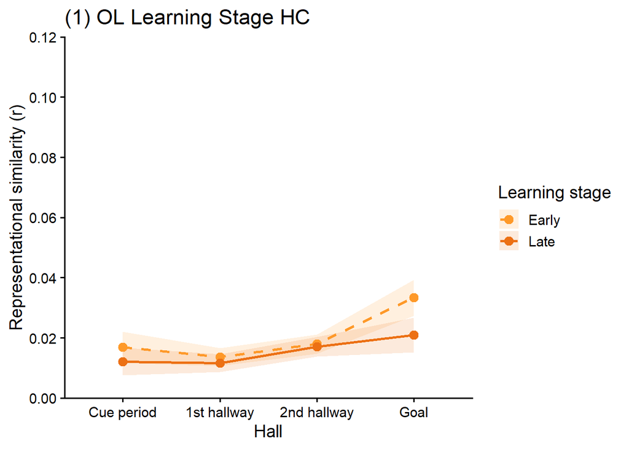

HIPPOCAMPUS NOL **************************

-> Repeated measures ANOVA Learning stage (Early,Late) x Hall (Cue period, 1st hall, 2nd hall, goal) (1) NOL HC

```
## # A tibble: 160 × 4
##    ID    learningStage Hall              RSA
##    <chr> <fct>         <fct>           <dbl>
##  1 s01   Early         Cue period   0.0351
##  2 s01   Early         1st hallway  0.00548
##  3 s01   Early         2nd hallway  0.0155
##  4 s01   Early         Goal         0.0253
##  5 s01   Late          Cue period   0.0137
##  6 s01   Late          1st hallway  0.0188
##  7 s01   Late          2nd hallway  0.0219
##  8 s01   Late          Goal         0.00652
##  9 s02   Early         Cue period  -0.000671
## 10 s02   Early         1st hallway -0.00711
## # ℹ 150 more rows
```

ANOVA

```
##               Effect                df1      df2     F       p   η.p
## 1      learningStage      learningStage 1.000000 1.271 = 0.274 0.063
## 2               Hall               Hall 2.003000 2.725 = 0.078 0.125
## 3 learningStage:Hall learningStage:Hall 2.241636 1.691 = 0.193 0.082
```

POST-HOCs

```
##                      contrast estimate    SE df    t.ratio    p.value     t
## 1   Cue.period - X1st.hallway    0.007 0.004 19  1.7085003 0.41531749  1.71
## 2   Cue.period - X2nd.hallway   -0.001 0.004 19 -0.2032334 1.00000000 -0.20
## 3           Cue.period - Goal   -0.002 0.004 19 -0.5473578 1.00000000 -0.55
## 4 X1st.hallway - X2nd.hallway   -0.007 0.002 19 -4.3836774 0.00191615 -4.38
## 5         X1st.hallway - Goal   -0.009 0.003 19 -2.8908530 0.04682483 -2.89
## 6         X2nd.hallway - Goal   -0.001 0.003 19 -0.3974098 1.00000000 -0.40
##   cohen_d  pHolms sig
## 1   0.382  = .415
## 2   0.045 = 1.000
## 3   0.122 = 1.000
## 4   0.980  = .002  **
## 5   0.646  = .047   *
## 6   0.089 = 1.000
```

DESCRIPTIVES

```
## # A tibble: 8 × 6
##   learningStage Hall            N  Mean    SD    SE
##   <fct>         <fct>       <int> <dbl> <dbl> <dbl>
## 1 Early         Cue period     20 0.022 0.02  0.004
## 2 Early         1st hallway    20 0.009 0.009 0.002
## 3 Early         2nd hallway    20 0.021 0.017 0.004
## 4 Early         Goal           20 0.023 0.027 0.006
## 5 Late          Cue period     20 0.013 0.023 0.005
## 6 Late          1st hallway    20 0.013 0.015 0.003
## 7 Late          2nd hallway    20 0.015 0.014 0.003
## 8 Late          Goal           20 0.015 0.022 0.005
```

PLOTTING NOL HIPPOCAMPUS (LearningStage x Hall)

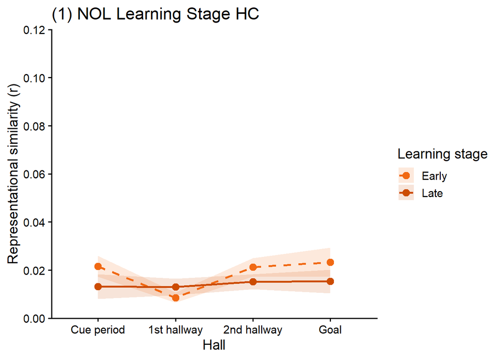

RSC OL **************************

-> Repeated meausures ANOVA Learning stage (Early,Late) x Hall (Cue period, 1st hall, 2nd hall, goal) (1) OL RSC

```
## # A tibble: 160 × 4
##    ID    learningStage Hall            RSA
##    <chr> <fct>         <fct>         <dbl>
##  1 s01   Early         Cue period  0.0639
##  2 s01   Early         1st hallway 0.0411
##  3 s01   Early         2nd hallway 0.0458
##  4 s01   Early         Goal        0.0933
##  5 s01   Late          Cue period  0.0648
##  6 s01   Late          1st hallway 0.0351
##  7 s01   Late          2nd hallway 0.0487
##  8 s01   Late          Goal        0.0572
##  9 s02   Early         Cue period  0.00340
## 10 s02   Early         1st hallway 0.0292
## # ℹ 150 more rows
```

ANOVA

```
##               Effect                df1      df2      F       p   η.p
## 1      learningStage      learningStage 1.000000  0.767 = 0.392 0.039
## 2               Hall               Hall 2.487325 11.021  < .001 0.367
## 3 learningStage:Hall learningStage:Hall 1.679780  0.196 = 0.785 0.010
```

POST-HOCs

```
##                      contrast estimate    SE df    t.ratio      p.value     t
## 1   Cue.period - X1st.hallway    0.004 0.006 19  0.5865827 5.643890e-01  0.59
## 2   Cue.period - X2nd.hallway   -0.010 0.007 19 -1.4028009 3.536120e-01 -1.40
## 3           Cue.period - Goal   -0.029 0.007 19 -4.3327606 1.792985e-03 -4.33
## 4 X1st.hallway - X2nd.hallway   -0.014 0.005 19 -3.1107590 2.302155e-02 -3.11
## 5         X1st.hallway - Goal   -0.033 0.005 19 -6.3576209 2.542395e-05 -6.36
## 6         X2nd.hallway - Goal   -0.018 0.007 19 -2.7981136 3.441212e-02 -2.80
##   cohen_d pHolms sig
## 1   0.131 = .564
## 2   0.314 = .354
## 3   0.969 = .002  **
## 4   0.696 = .023   *
## 5   1.422 < .001 ***
## 6   0.626 = .034   *
```

DESCRIPTIVES

```
## # A tibble: 8 × 6
##   learningStage Hall            N  Mean    SD    SE
##   <fct>         <fct>       <int> <dbl> <dbl> <dbl>
## 1 Early         Cue period     20 0.058 0.035 0.008
## 2 Early         1st hallway    20 0.048 0.028 0.006
## 3 Early         2nd hallway    20 0.067 0.042 0.009
## 4 Early         Goal           20 0.084 0.044 0.01
## 5 Late          Cue period     20 0.047 0.039 0.009
## 6 Late          1st hallway    20 0.049 0.031 0.007
## 7 Late          2nd hallway    20 0.058 0.048 0.011
## 8 Late          Goal           20 0.078 0.053 0.012
```

PLOTTING OL RSC (LearningStage x Hall)

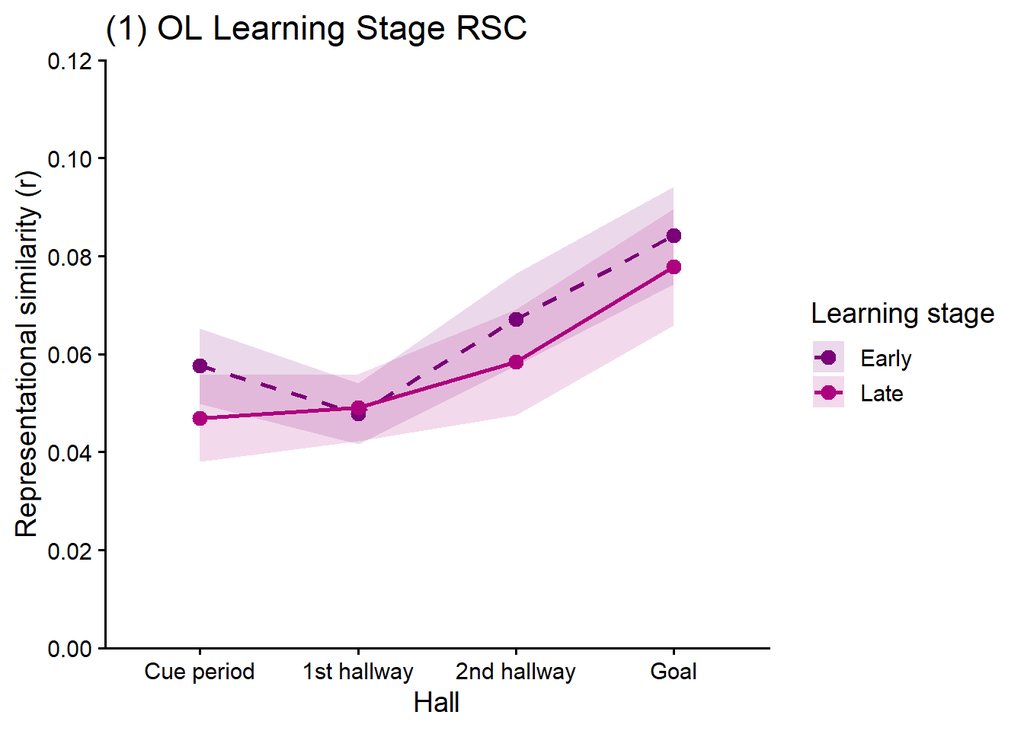

RSC NOL **************************

-> Repeated meausures ANOVA Learning stage (Early,Late) x Hall (Cue period, 1st hall, 2nd hall, goal) (1) NOL RSC

```
## # A tibble: 160 × 4
##    ID    learningStage Hall            RSA
##    <chr> <fct>         <fct>         <dbl>
##  1 s01   Early         Cue period  0.0882
##  2 s01   Early         1st hallway 0.0576
##  3 s01   Early         2nd hallway 0.0595
##  4 s01   Early         Goal        0.0785
##  5 s01   Late          Cue period  0.0691
##  6 s01   Late          1st hallway 0.0813
##  7 s01   Late          2nd hallway 0.0974
##  8 s01   Late          Goal        0.0464
##  9 s02   Early         Cue period  0.0271
## 10 s02   Early         1st hallway 0.00905
## # ℹ 150 more rows
```

ANOVA

```
##               Effect                df1      df2     F       p   η.p
## 1      learningStage      learningStage 1.000000 0.250 = 0.623 0.013
## 2               Hall               Hall 2.635728 3.170 = 0.038 0.143
## 3 learningStage:Hall learningStage:Hall 2.151388 0.369 = 0.709 0.019
```

POST-HOCs

```
##                      contrast estimate    SE df    t.ratio   p.value     t
## 1   Cue.period - X1st.hallway    0.006 0.006 19  0.9818827 0.6769924  0.98
## 2   Cue.period - X2nd.hallway   -0.008 0.005 19 -1.4839264 0.6169155 -1.48
## 3           Cue.period - Goal   -0.009 0.006 19 -1.4228809 0.6169155 -1.42
## 4 X1st.hallway - X2nd.hallway   -0.014 0.004 19 -3.4068978 0.0177477 -3.41
## 5         X1st.hallway - Goal   -0.015 0.006 19 -2.4847377 0.1122528 -2.48
## 6         X2nd.hallway - Goal   -0.001 0.005 19 -0.1679713 0.8683809 -0.17
##   cohen_d pHolms sig
## 1   0.220 = .677
## 2   0.332 = .617
## 3   0.318 = .617
## 4   0.762 = .018   *
## 5   0.556 = .112
## 6   0.038 = .868
```

DESCRIPTIVES

```
## # A tibble: 8 × 6
##   learningStage Hall            N  Mean    SD    SE
##   <fct>         <fct>       <int> <dbl> <dbl> <dbl>
## 1 Early         Cue period     20 0.051 0.039 0.009
## 2 Early         1st hallway    20 0.041 0.026 0.006
## 3 Early         2nd hallway    20 0.063 0.04  0.009
## 4 Early         Goal           20 0.058 0.047 0.011
## 5 Late          Cue period     20 0.054 0.042 0.009
## 6 Late          1st hallway    20 0.051 0.027 0.006
## 7 Late          2nd hallway    20 0.058 0.033 0.007
## 8 Late          Goal           20 0.064 0.047 0.01
```

PLOTTING NOL RSC (LearningStage x Hall)

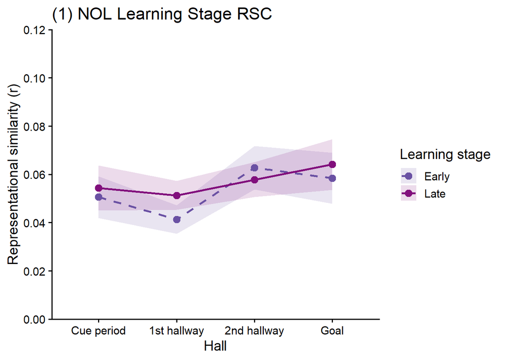

RSComplex OL **************************

-> Repeated meausures ANOVA Learning stage (Early,Late) x Hall (Cue period, 1st hall, 2nd hall, goal) (1) OL RSComplex

```
## # A tibble: 160 × 4
##    ID    learningStage Hall             RSA
##    <chr> <fct>         <fct>          <dbl>
##  1 s01   Early         Cue period   0.0465
##  2 s01   Early         1st hallway  0.0534
##  3 s01   Early         2nd hallway  0.0361
##  4 s01   Early         Goal         0.0601
##  5 s01   Late          Cue period   0.0693
##  6 s01   Late          1st hallway  0.0587
##  7 s01   Late          2nd hallway  0.0447
##  8 s01   Late          Goal         0.0541
##  9 s02   Early         Cue period  -0.00172
## 10 s02   Early         1st hallway  0.0448
## # ℹ 150 more rows
```

ANOVA

```
##               Effect                df1      df2     F       p   η.p
## 1      learningStage      learningStage 1.000000 1.537 = 0.230 0.075
## 2               Hall               Hall 1.975160 4.286 = 0.021 0.184
## 3 learningStage:Hall learningStage:Hall 1.686408 0.366 = 0.661 0.019
```

POST-HOCs

```
##                      contrast estimate    SE df     t.ratio    p.value     t
## 1   Cue.period - X1st.hallway   -0.014 0.011 19 -1.26967411 0.48767319 -1.27
## 2   Cue.period - X2nd.hallway   -0.028 0.010 19 -2.74698182 0.06409280 -2.75
## 3           Cue.period - Goal   -0.028 0.008 19 -3.48143170 0.01499045 -3.48
## 4 X1st.hallway - X2nd.hallway   -0.014 0.005 19 -2.71951039 0.06409280 -2.72
## 5         X1st.hallway - Goal   -0.013 0.009 19 -1.45293816 0.48767319 -1.45
## 6         X2nd.hallway - Goal    0.000 0.009 19  0.01151371 0.99093363  0.01
##   cohen_d pHolms sig
## 1   0.284 = .488
## 2   0.614 = .064
## 3   0.778 = .015   *
## 4   0.608 = .064
## 5   0.325 = .488
## 6   0.003 = .991
```

DESCRIPTIVES

```
## # A tibble: 8 × 6
##   learningStage Hall            N  Mean    SD    SE
##   <fct>         <fct>       <int> <dbl> <dbl> <dbl>
## 1 Early         Cue period     20 0.067 0.049 0.011
## 2 Early         1st hallway    20 0.075 0.039 0.009
## 3 Early         2nd hallway    20 0.096 0.045 0.01
## 4 Early         Goal           20 0.088 0.063 0.014
## 5 Late          Cue period     20 0.053 0.052 0.012
## 6 Late          1st hallway    20 0.074 0.042 0.009
## 7 Late          2nd hallway    20 0.08  0.055 0.012
## 8 Late          Goal           20 0.088 0.056 0.013
```

PLOTTING OL RSComplex (LearningStage x Hall)

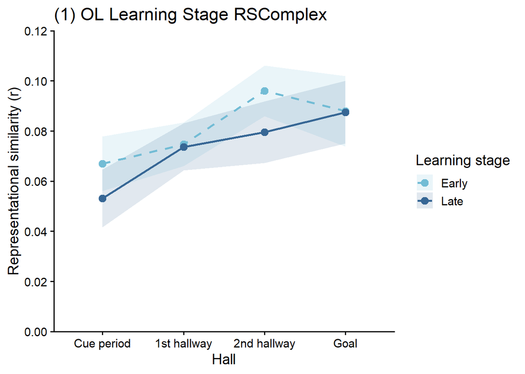

RSComplex NOL **************************

-> Repeated meausures ANOVA Learning stage (Early,Late) x Hall (Cue period, 1st hall, 2nd hall, goal) (1) NOL RSComplex

```
## # A tibble: 160 × 4
##    ID    learningStage Hall           RSA
##    <chr> <fct>         <fct>        <dbl>
##  1 s01   Early         Cue period  0.116
##  2 s01   Early         1st hallway 0.0383
##  3 s01   Early         2nd hallway 0.0405
##  4 s01   Early         Goal        0.0629
##  5 s01   Late          Cue period  0.0624
##  6 s01   Late          1st hallway 0.0908
##  7 s01   Late          2nd hallway 0.0886
##  8 s01   Late          Goal        0.0505
##  9 s02   Early         Cue period  0.0292
## 10 s02   Early         1st hallway 0.0417
## # ℹ 150 more rows
```

ANOVA

```
##               Effect                df1      df2     F       p   η.p
## 1      learningStage      learningStage 1.000000 0.214 = 0.649 0.011
## 2               Hall               Hall 2.045097 2.088 = 0.137 0.099
## 3 learningStage:Hall learningStage:Hall 1.906409 3.032 = 0.063 0.138
```

POST-HOCs

```
##                      contrast estimate    SE df    t.ratio    p.value     t
## 1   Cue.period - X1st.hallway   -0.003 0.010 19 -0.2786226 0.87042179 -0.28
## 2   Cue.period - X2nd.hallway   -0.017 0.008 19 -2.1132258 0.24018944 -2.11
## 3           Cue.period - Goal   -0.012 0.009 19 -1.3923601 0.71958482 -1.39
## 4 X1st.hallway - X2nd.hallway   -0.015 0.004 19 -3.3241632 0.02139462 -3.32
## 5         X1st.hallway - Goal   -0.009 0.008 19 -1.2067207 0.72704997 -1.21
## 6         X2nd.hallway - Goal    0.006 0.007 19  0.7971539 0.87042179  0.80
##   cohen_d pHolms sig
## 1   0.062 = .870
## 2   0.473 = .240
## 3   0.311 = .720
## 4   0.743 = .021   *
## 5   0.270 = .727
## 6   0.178 = .870
```

DESCRIPTIVES

```
## # A tibble: 8 × 6
##   learningStage Hall            N  Mean    SD    SE
##   <fct>         <fct>       <int> <dbl> <dbl> <dbl>
## 1 Early         Cue period     20 0.061 0.052 0.012
## 2 Early         1st hallway    20 0.061 0.039 0.009
## 3 Early         2nd hallway    20 0.088 0.053 0.012
## 4 Early         Goal           20 0.06  0.057 0.013
## 5 Late          Cue period     20 0.061 0.044 0.01
## 6 Late          1st hallway    20 0.068 0.032 0.007
## 7 Late          2nd hallway    20 0.069 0.033 0.007
## 8 Late          Goal           20 0.087 0.051 0.011
```

PLOTTING NOL RSComplex (LearningStage x Hall) ********** <3 ********************

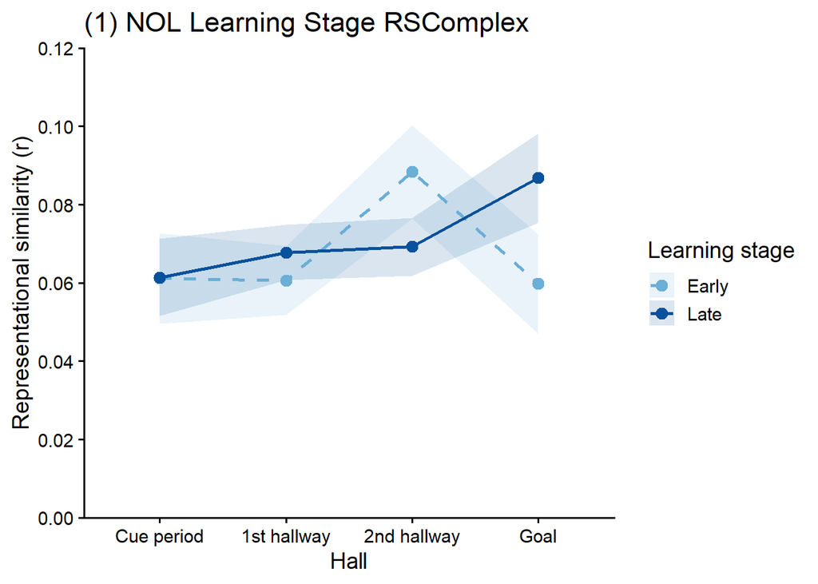

***************************************** 2) NATURE OF REPRESENTATIONS **************************

2a) 3 ROIs: HC vs RSC vs RSComplex ************************** # OL EARLY

```
## # A tibble: 240 × 4
##    ID    ROI         Hall            RSA
##    <chr> <fct>       <fct>         <dbl>
##  1 s01   Hippocampus Cue period  0.0240
##  2 s01   Hippocampus 1st hallway 0.00717
##  3 s01   Hippocampus 2nd hallway 0.0173
##  4 s01   Hippocampus Goal        0.0281
##  5 s01   RSC         Cue period  0.0639
##  6 s01   RSC         1st hallway 0.0411
##  7 s01   RSC         2nd hallway 0.0458
##  8 s01   RSC         Goal        0.0933
##  9 s01   Complex     Cue period  0.0465
## 10 s01   Complex     1st hallway 0.0534
## # ℹ 230 more rows
```

ANOVA

```
##     Effect      df1      df2      F       p   η.p
## 1      ROI      ROI 1.504298 81.214  < .001 0.810
## 2     Hall     Hall 1.844633  3.685 = 0.038 0.162
## 3 ROI:Hall ROI:Hall 3.202280  3.383 = 0.021 0.151
```

- POST-HOCS

```
##                                               contrast estimate    SE df     t
## 1    Cue.period Hippocampus - X1st.hallway Hippocampus    0.003 0.005 19  0.65
## 2    Cue.period Hippocampus - X2nd.hallway Hippocampus   -0.001 0.005 19 -0.21
## 3            Cue.period Hippocampus - Goal Hippocampus   -0.016 0.005 19 -3.03
## 4              Cue.period Hippocampus - Cue.period RSC   -0.041 0.006 19 -7.07
## 5            Cue.period Hippocampus - X1st.hallway RSC   -0.031 0.007 19 -4.55
## 6            Cue.period Hippocampus - X2nd.hallway RSC   -0.050 0.009 19 -5.50
## 7                    Cue.period Hippocampus - Goal RSC   -0.067 0.009 19 -7.35
## 8          Cue.period Hippocampus - Cue.period Complex   -0.050 0.008 19 -6.24
## 9        Cue.period Hippocampus - X1st.hallway Complex   -0.058 0.010 19 -6.07
## 10       Cue.period Hippocampus - X2nd.hallway Complex   -0.079 0.010 19 -7.89
## 11               Cue.period Hippocampus - Goal Complex   -0.071 0.014 19 -5.21
## 12 X1st.hallway Hippocampus - X2nd.hallway Hippocampus   -0.004 0.002 19 -2.03
## 13         X1st.hallway Hippocampus - Goal Hippocampus   -0.020 0.005 19 -3.64
## 14           X1st.hallway Hippocampus - Cue.period RSC   -0.044 0.007 19 -6.21
```

[output cut: 119 more lines]

DESCRIPTIVES

```
## # A tibble: 12 × 6
##    ROI         Hall            N  Mean    SD    SE
##    <fct>       <fct>       <int> <dbl> <dbl> <dbl>
##  1 Hippocampus Cue period     20 0.017 0.023 0.005
##  2 Hippocampus 1st hallway    20 0.014 0.013 0.003
##  3 Hippocampus 2nd hallway    20 0.018 0.014 0.003
##  4 Hippocampus Goal           20 0.033 0.027 0.006
##  5 RSC         Cue period     20 0.058 0.035 0.008
##  6 RSC         1st hallway    20 0.048 0.028 0.006
##  7 RSC         2nd hallway    20 0.067 0.042 0.009
##  8 RSC         Goal           20 0.084 0.044 0.01
##  9 Complex     Cue period     20 0.067 0.049 0.011
## 10 Complex     1st hallway    20 0.075 0.039 0.009
## 11 Complex     2nd hallway    20 0.096 0.045 0.01
## 12 Complex     Goal           20 0.088 0.063 0.014
```

# PLOTTING OL EARLY HC vs RSC vs RSComplex

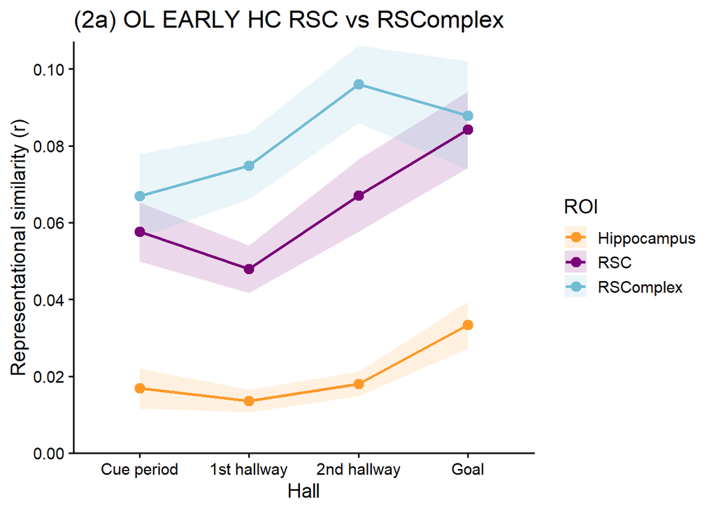

2a) HC vs RSC vs RSComplex

# OL LATE

```
## # A tibble: 240 × 4
##    ID    ROI         Hall            RSA
##    <chr> <fct>       <fct>         <dbl>
##  1 s01   Hippocampus Cue period  0.0462
##  2 s01   Hippocampus 1st hallway 0.00419
##  3 s01   Hippocampus 2nd hallway 0.0246
##  4 s01   Hippocampus Goal        0.0263
##  5 s01   RSC         Cue period  0.0648
##  6 s01   RSC         1st hallway 0.0351
##  7 s01   RSC         2nd hallway 0.0487
##  8 s01   RSC         Goal        0.0572
##  9 s01   Complex     Cue period  0.0693
## 10 s01   Complex     1st hallway 0.0587
## # ℹ 230 more rows
```

ANOVA

```
##     Effect      df1      df2      F       p   η.p
## 1      ROI      ROI 1.555835 83.976  < .001 0.815
## 2     Hall     Hall 2.005967  2.809 = 0.073 0.129
## 3 ROI:Hall ROI:Hall 2.458546  1.891 = 0.154 0.091
```

- POST-HOCS

```
##                                               contrast estimate    SE df     t
## 1    Cue.period Hippocampus - X1st.hallway Hippocampus    0.001 0.004 19  0.14
## 2    Cue.period Hippocampus - X2nd.hallway Hippocampus   -0.005 0.005 19 -1.09
## 3            Cue.period Hippocampus - Goal Hippocampus   -0.009 0.006 19 -1.53
## 4              Cue.period Hippocampus - Cue.period RSC   -0.035 0.006 19 -5.56
## 5            Cue.period Hippocampus - X1st.hallway RSC   -0.037 0.008 19 -4.87
## 6            Cue.period Hippocampus - X2nd.hallway RSC   -0.046 0.010 19 -4.43
## 7                    Cue.period Hippocampus - Goal RSC   -0.066 0.012 19 -5.47
## 8          Cue.period Hippocampus - Cue.period Complex   -0.041 0.008 19 -4.85
## 9        Cue.period Hippocampus - X1st.hallway Complex   -0.062 0.010 19 -6.12
## 10       Cue.period Hippocampus - X2nd.hallway Complex   -0.067 0.013 19 -5.15
## 11               Cue.period Hippocampus - Goal Complex   -0.075 0.012 19 -6.14
## 12 X1st.hallway Hippocampus - X2nd.hallway Hippocampus   -0.005 0.003 19 -1.79
## 13         X1st.hallway Hippocampus - Goal Hippocampus   -0.009 0.004 19 -2.07
## 14           X1st.hallway Hippocampus - Cue.period RSC   -0.035 0.008 19 -4.65
```

[output cut: 119 more lines]

DESCRIPTIVES

```
## # A tibble: 12 × 6
##    ROI         Hall            N  Mean    SD    SE
##    <fct>       <fct>       <int> <dbl> <dbl> <dbl>
##  1 Hippocampus Cue period     20 0.012 0.021 0.005
##  2 Hippocampus 1st hallway    20 0.012 0.013 0.003
##  3 Hippocampus 2nd hallway    20 0.017 0.015 0.003
##  4 Hippocampus Goal           20 0.021 0.026 0.006
##  5 RSC         Cue period     20 0.047 0.039 0.009
##  6 RSC         1st hallway    20 0.049 0.031 0.007
##  7 RSC         2nd hallway    20 0.058 0.048 0.011
##  8 RSC         Goal           20 0.078 0.053 0.012
##  9 Complex     Cue period     20 0.053 0.052 0.012
## 10 Complex     1st hallway    20 0.074 0.042 0.009
## 11 Complex     2nd hallway    20 0.08  0.055 0.012
## 12 Complex     Goal           20 0.088 0.056 0.013
```

# PLOTTING OL LATE HC vs RSC vs RSComplex

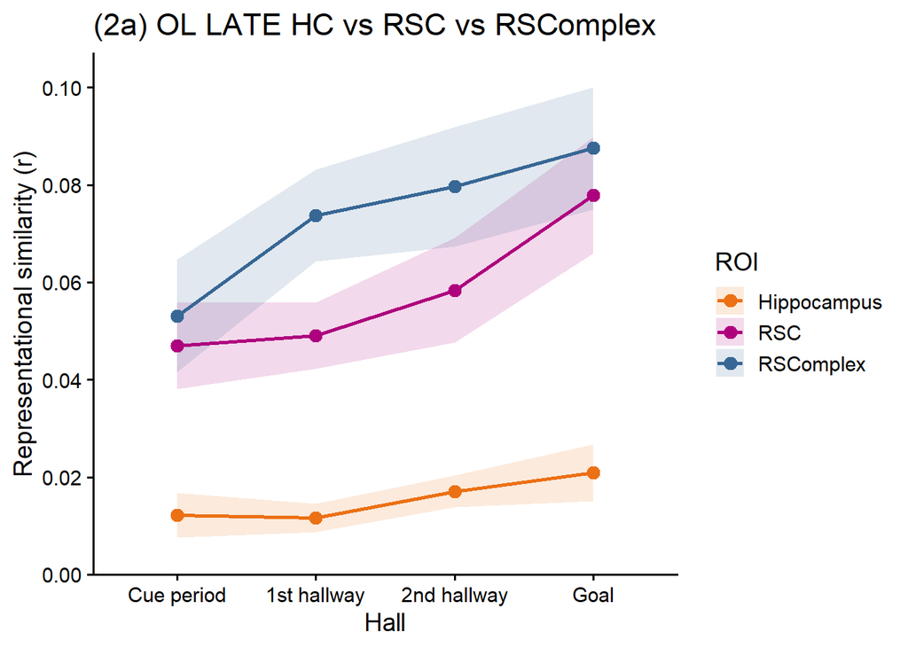

******************************** 2a) HC vs RSC vs RSComplex

# NOL Early

```
## # A tibble: 240 × 4
##    ID    ROI         Hall            RSA
##    <chr> <fct>       <fct>         <dbl>
##  1 s01   Hippocampus Cue period  0.0351
##  2 s01   Hippocampus 1st hallway 0.00548
##  3 s01   Hippocampus 2nd hallway 0.0155
##  4 s01   Hippocampus Goal        0.0253
##  5 s01   RSC         Cue period  0.0882
##  6 s01   RSC         1st hallway 0.0576
##  7 s01   RSC         2nd hallway 0.0595
##  8 s01   RSC         Goal        0.0785
##  9 s01   Complex     Cue period  0.116
## 10 s01   Complex     1st hallway 0.0383
## # ℹ 230 more rows
```

ANOVA

```
##     Effect      df1      df2      F       p   η.p
## 1      ROI      ROI 1.407702 43.550  < .001 0.696
## 2     Hall     Hall 2.051497  3.047 = 0.058 0.138
## 3 ROI:Hall ROI:Hall 3.304937  2.961 = 0.034 0.135
```

- POST-HOCS *** Sig interaction ***

```
##                                               contrast estimate    SE df     t
## 1    Cue.period Hippocampus - X1st.hallway Hippocampus    0.013 0.005 19  2.86
## 2    Cue.period Hippocampus - X2nd.hallway Hippocampus    0.000 0.005 19  0.07
## 3            Cue.period Hippocampus - Goal Hippocampus   -0.002 0.004 19 -0.40
## 4              Cue.period Hippocampus - Cue.period RSC   -0.029 0.006 19 -4.51
## 5            Cue.period Hippocampus - X1st.hallway RSC   -0.020 0.006 19 -3.52
## 6            Cue.period Hippocampus - X2nd.hallway RSC   -0.041 0.008 19 -5.31
## 7                    Cue.period Hippocampus - Goal RSC   -0.037 0.009 19 -4.25
## 8          Cue.period Hippocampus - Cue.period Complex   -0.040 0.009 19 -4.30
## 9        Cue.period Hippocampus - X1st.hallway Complex   -0.039 0.009 19 -4.27
## 10       Cue.period Hippocampus - X2nd.hallway Complex   -0.067 0.011 19 -5.88
## 11               Cue.period Hippocampus - Goal Complex   -0.038 0.011 19 -3.59
## 12 X1st.hallway Hippocampus - X2nd.hallway Hippocampus   -0.013 0.003 19 -4.98
## 13         X1st.hallway Hippocampus - Goal Hippocampus   -0.015 0.005 19 -2.79
## 14           X1st.hallway Hippocampus - Cue.period RSC   -0.042 0.008 19 -5.03
```

[output cut: 119 more lines]

DESCRIPTIVES

```
## # A tibble: 12 × 6
##    ROI         Hall            N  Mean    SD    SE
##    <fct>       <fct>       <int> <dbl> <dbl> <dbl>
##  1 Hippocampus Cue period     20 0.022 0.02  0.004
##  2 Hippocampus 1st hallway    20 0.009 0.009 0.002
##  3 Hippocampus 2nd hallway    20 0.021 0.017 0.004
##  4 Hippocampus Goal           20 0.023 0.027 0.006
##  5 RSC         Cue period     20 0.051 0.039 0.009
##  6 RSC         1st hallway    20 0.041 0.026 0.006
##  7 RSC         2nd hallway    20 0.063 0.04  0.009
##  8 RSC         Goal           20 0.058 0.047 0.011
##  9 Complex     Cue period     20 0.061 0.052 0.012
## 10 Complex     1st hallway    20 0.061 0.039 0.009
## 11 Complex     2nd hallway    20 0.088 0.053 0.012
## 12 Complex     Goal           20 0.06  0.057 0.013
```

PLOTTING NOL Early HC vs RSC vs RSComplex

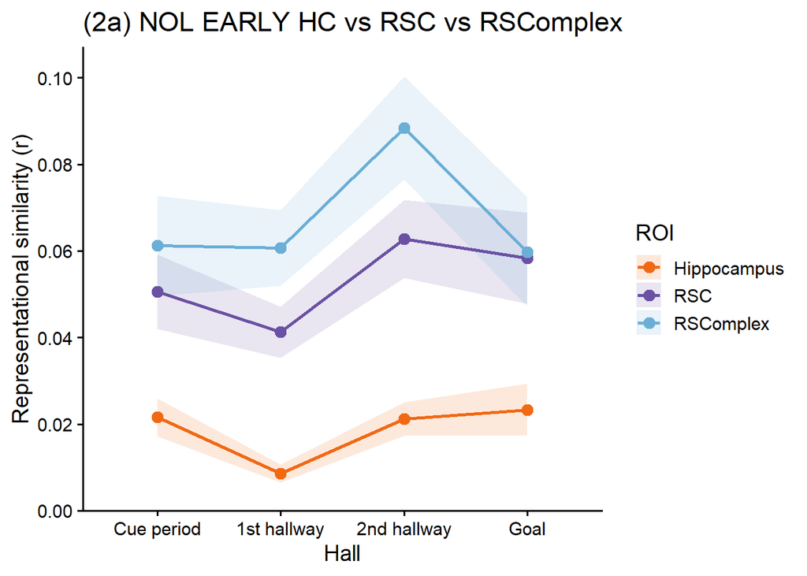

2a) HC vs RSC vs Complex

# NOL LATE

```
## # A tibble: 240 × 4
##    ID    ROI         Hall            RSA
##    <chr> <fct>       <fct>         <dbl>
##  1 s01   Hippocampus Cue period  0.0137
##  2 s01   Hippocampus 1st hallway 0.0188
##  3 s01   Hippocampus 2nd hallway 0.0219
##  4 s01   Hippocampus Goal        0.00652
##  5 s01   RSC         Cue period  0.0691
##  6 s01   RSC         1st hallway 0.0813
##  7 s01   RSC         2nd hallway 0.0974
##  8 s01   RSC         Goal        0.0464
##  9 s01   Complex     Cue period  0.0624
## 10 s01   Complex     1st hallway 0.0908
## # ℹ 230 more rows
```

ANOVA

```
##     Effect      df1      df2      F       p   η.p
## 1      ROI      ROI 1.491548 71.629  < .001 0.790
## 2     Hall     Hall 2.238247  1.059 = 0.362 0.053
## 3 ROI:Hall ROI:Hall 3.397965  1.818 = 0.146 0.087
```

- POST-HOCS

```
##                                               contrast estimate    SE df     t
## 1    Cue.period Hippocampus - X1st.hallway Hippocampus    0.000 0.006 19  0.02
## 2    Cue.period Hippocampus - X2nd.hallway Hippocampus   -0.002 0.005 19 -0.40
## 3            Cue.period Hippocampus - Goal Hippocampus   -0.002 0.006 19 -0.38
## 4              Cue.period Hippocampus - Cue.period RSC   -0.041 0.008 19 -5.19
## 5            Cue.period Hippocampus - X1st.hallway RSC   -0.038 0.009 19 -4.43
## 6            Cue.period Hippocampus - X2nd.hallway RSC   -0.045 0.009 19 -4.77
## 7                    Cue.period Hippocampus - Goal RSC   -0.051 0.012 19 -4.29
## 8          Cue.period Hippocampus - Cue.period Complex   -0.048 0.009 19 -5.45
## 9        Cue.period Hippocampus - X1st.hallway Complex   -0.055 0.010 19 -5.43
## 10       Cue.period Hippocampus - X2nd.hallway Complex   -0.056 0.010 19 -5.83
## 11               Cue.period Hippocampus - Goal Complex   -0.074 0.014 19 -5.40
## 12 X1st.hallway Hippocampus - X2nd.hallway Hippocampus   -0.002 0.002 19 -0.95
## 13         X1st.hallway Hippocampus - Goal Hippocampus   -0.002 0.004 19 -0.56
## 14           X1st.hallway Hippocampus - Cue.period RSC   -0.041 0.009 19 -4.73
```

[output cut: 119 more lines]

DESCRIPTIVES

```
## # A tibble: 12 × 6
##    ROI         Hall            N  Mean    SD    SE
##    <fct>       <fct>       <int> <dbl> <dbl> <dbl>
##  1 Hippocampus Cue period     20 0.013 0.023 0.005
##  2 Hippocampus 1st hallway    20 0.013 0.015 0.003
##  3 Hippocampus 2nd hallway    20 0.015 0.014 0.003
##  4 Hippocampus Goal           20 0.015 0.022 0.005
##  5 RSC         Cue period     20 0.054 0.042 0.009
##  6 RSC         1st hallway    20 0.051 0.027 0.006
##  7 RSC         2nd hallway    20 0.058 0.033 0.007
##  8 RSC         Goal           20 0.064 0.047 0.01
##  9 Complex     Cue period     20 0.061 0.044 0.01
## 10 Complex     1st hallway    20 0.068 0.032 0.007
## 11 Complex     2nd hallway    20 0.069 0.033 0.007
## 12 Complex     Goal           20 0.087 0.051 0.011
```

# PLOTTING NOL LATE HC vs RSC vs Complex

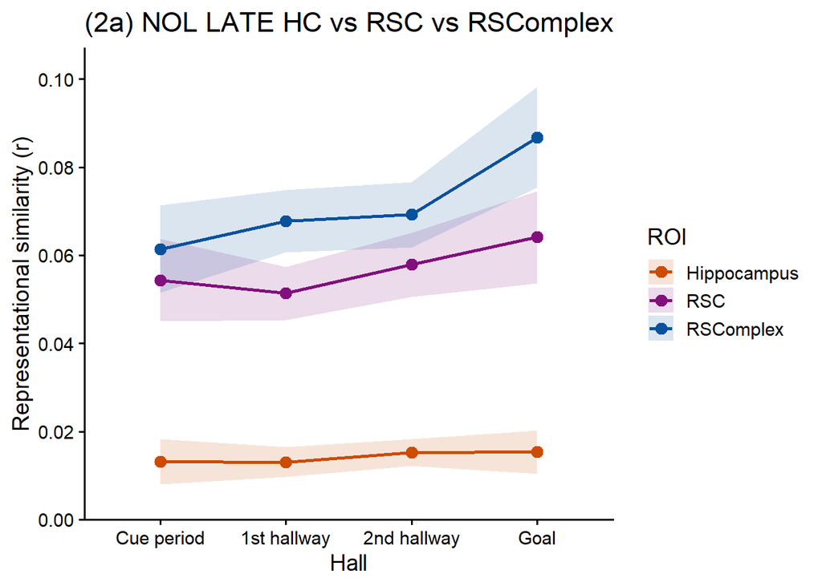

2. NATURE OF REPRESENTATIONS ****************************

(2b) REPULSION, SEPARATION OR COMPLETION REPRESENTATIONS? ****************************************************** # 2b.1) Hippocampus (EARLY+LATE)

paired t-tests (for both Early & Late), Cohen’s d, CI’s 95%…

Data table

# 2b.2) RSC (EARLY+LATE)

paired t-tests (for both Early & Late), Cohen’s d, CI’s 95%…

Data table

# 2b.3) RSComplex (EARLY+LATE)

paired t-tests (for both Early & Late), Cohen’s d, CI’s 95%…

Data table

# Cleaning data: all 3 ROIs together 4 plotting (EARLY)

1. Data frame rearranged
2. Prepare and define X-Axis order

# PLOTTING

## Early

Dot plots ****************************************************

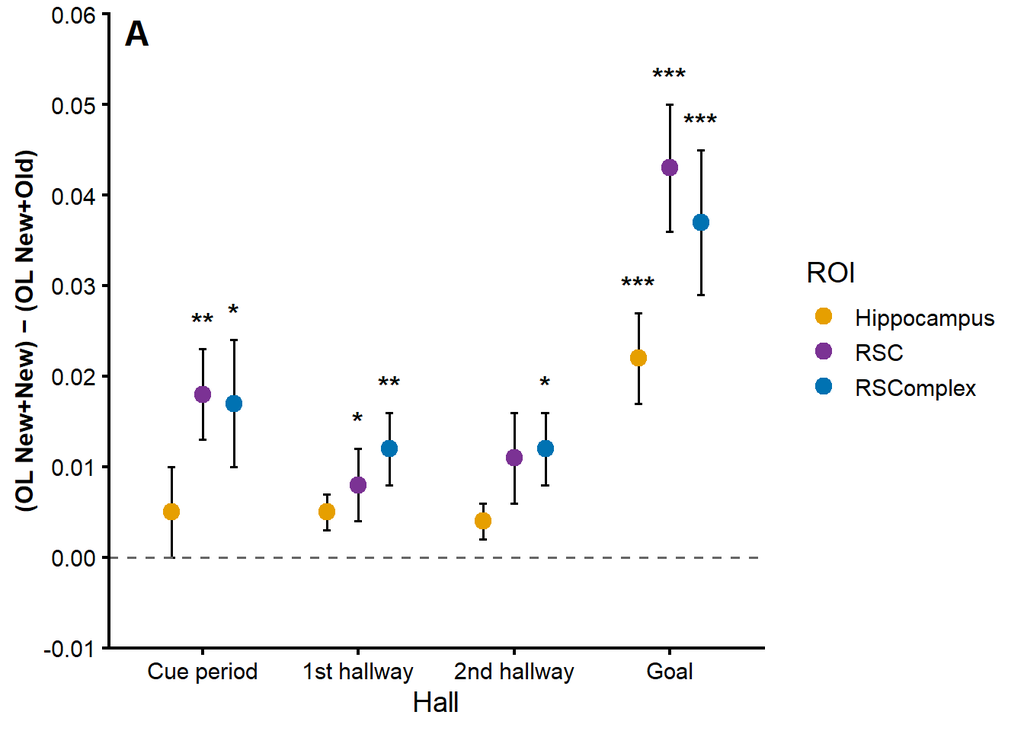

Dot plot (LATE) collapsed halls- v2 (02/05/2026) **needs to fix the asterisks** **************************************************

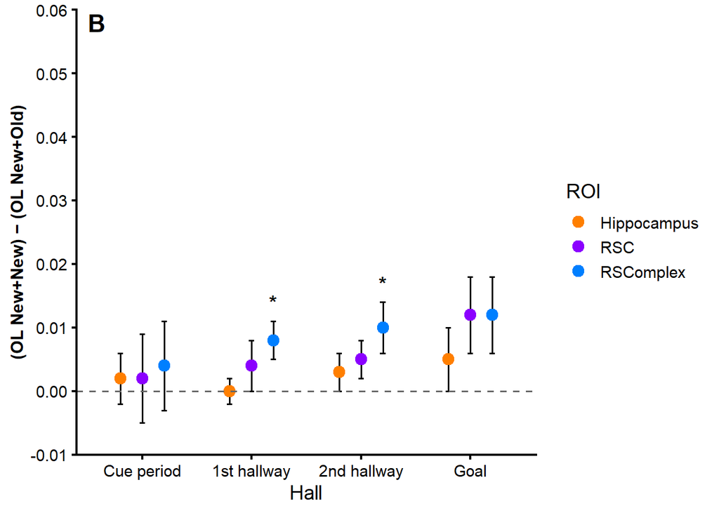

# 3) CORRELATIONS (with no corrections)

# a) OL Early

HIPPOCAMPUS + RSC

## MASKING TRIANGLES

## PLOTTING

# CORRELATION MATRIX HC + RSC OL EARLY

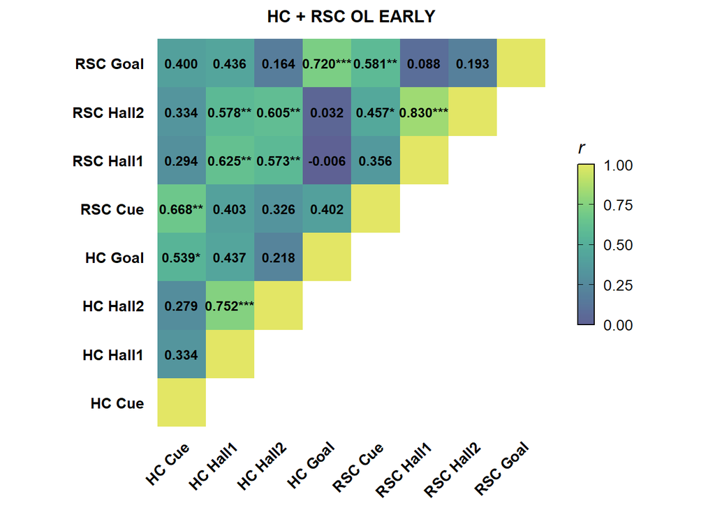

### HIPPOCAMPUS + RSC

# OL Late

HC + RSC OL LATE MATRIX

## MASKING TRIANGLES

## PLOTTING

# CORRELATION MATRIX HC + RSC OL LATE

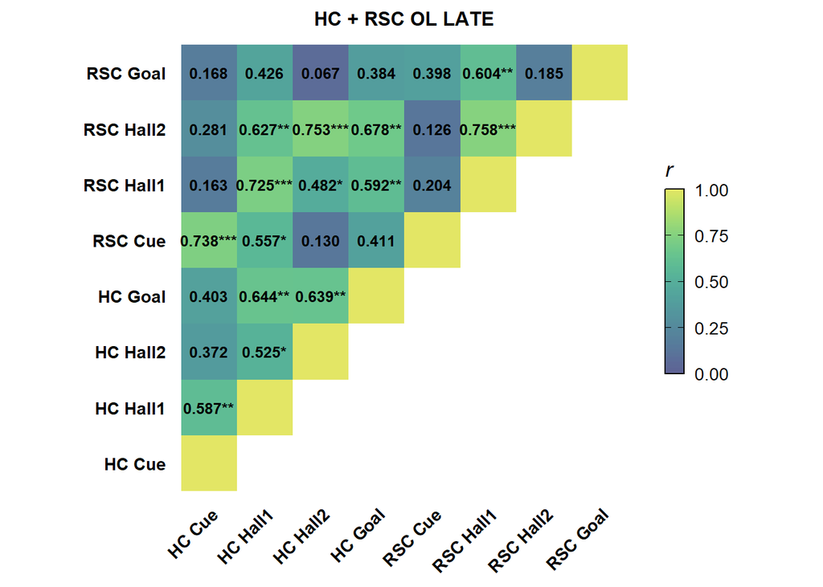

### HIPPOCAMPUS + RSCOMPLEX

# OL Early

HC + RSComplex OL EARLY MATRIX

## MASKING TRIANGLES

## PLOTTING

# CORRELATION MATRIX HC + RSComplex OL EARLY

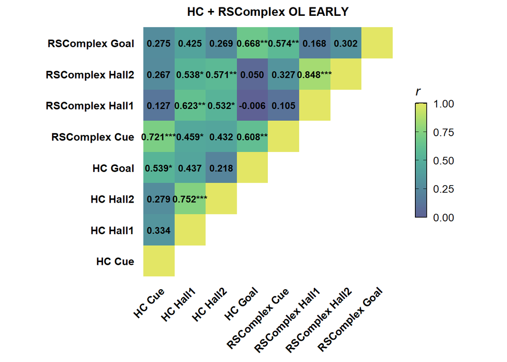

### HIPPOCAMPUS + RSComplex

# OL Late

HC + RSComplex OL LATE MATRIX

## MASKING TRIANGLES

## PLOTTING

# CORRELATION MATRIX HC + RSComplex OL LATE

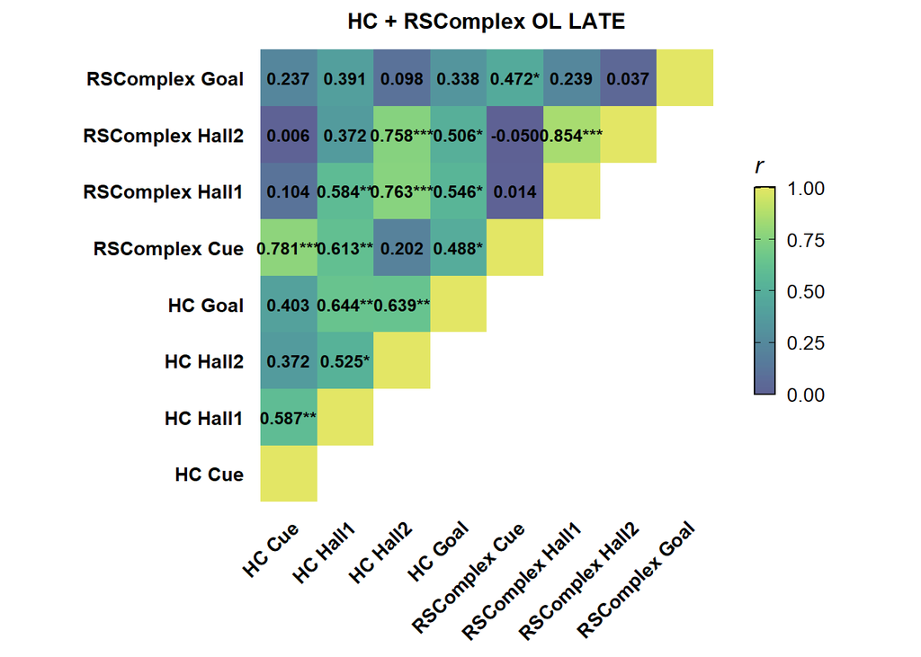

## RSC + RSComplex

# OL Early

# RSC + RSComplex OL EARLY

## MASKING TRIANGLES

## PLOTTING

# CORRELATION MATRIX RSC + RSComplex OL EARLY

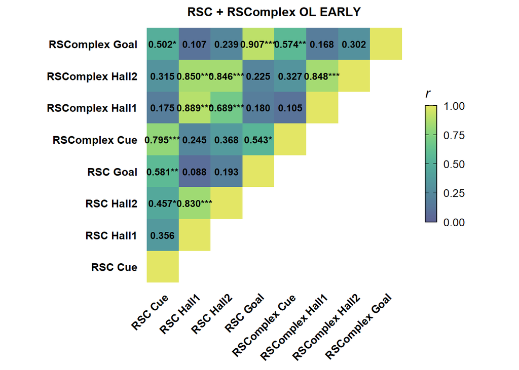

### RSC + RSComplex

# OL Late

RSC + RSComplex OL LATE MATRIX

## MASKING TRIANGLES

## PLOTTING

# CORRELATION MATRIX RSC + RSComplex OL LATE

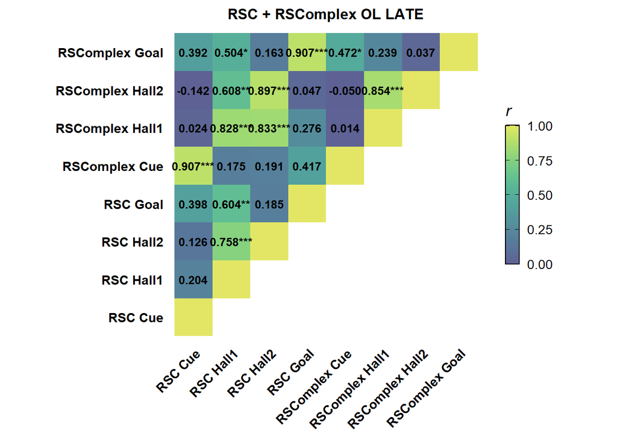

# 3. b) NON-OVERLAPPING

## NOL EARLY

HC + RSC

## MASKING TRIANGLES

## PLOTTING

# CORRELATION MATRIX HC + RSC NOL EARLY

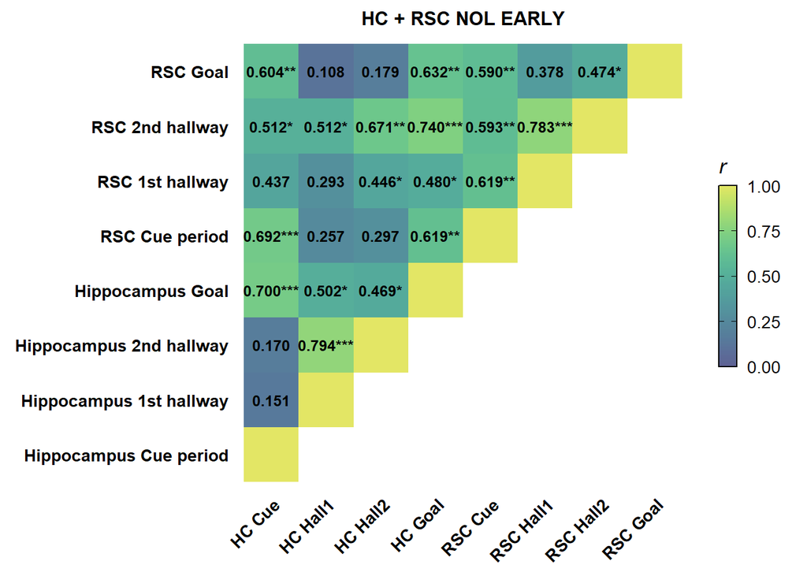

### HIPPOCAMPUS + RSC

HC + RSC NOL LATE MATRIX

## MASKING TRIANGLES

## PLOTTING

# CORRELATION MATRIX HC + RSC NOL LATE

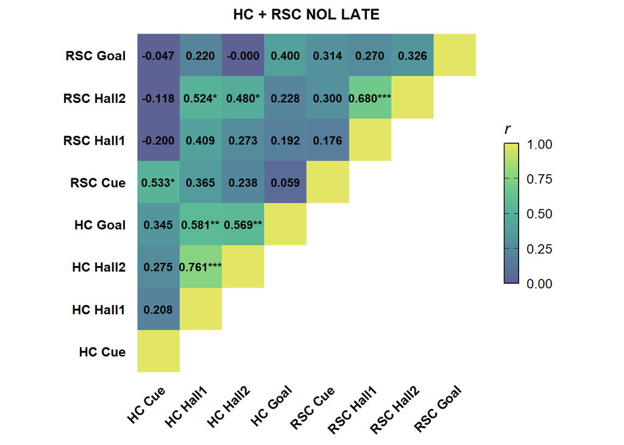

### HIPPOCAMPUS + RSCOMPLEX

HC + RSComplex NOL EARLY MATRIX

## MASKING TRIANGLES

## PLOTTING

# CORRELATION MATRIX HC + RSComplex NOL EARLY

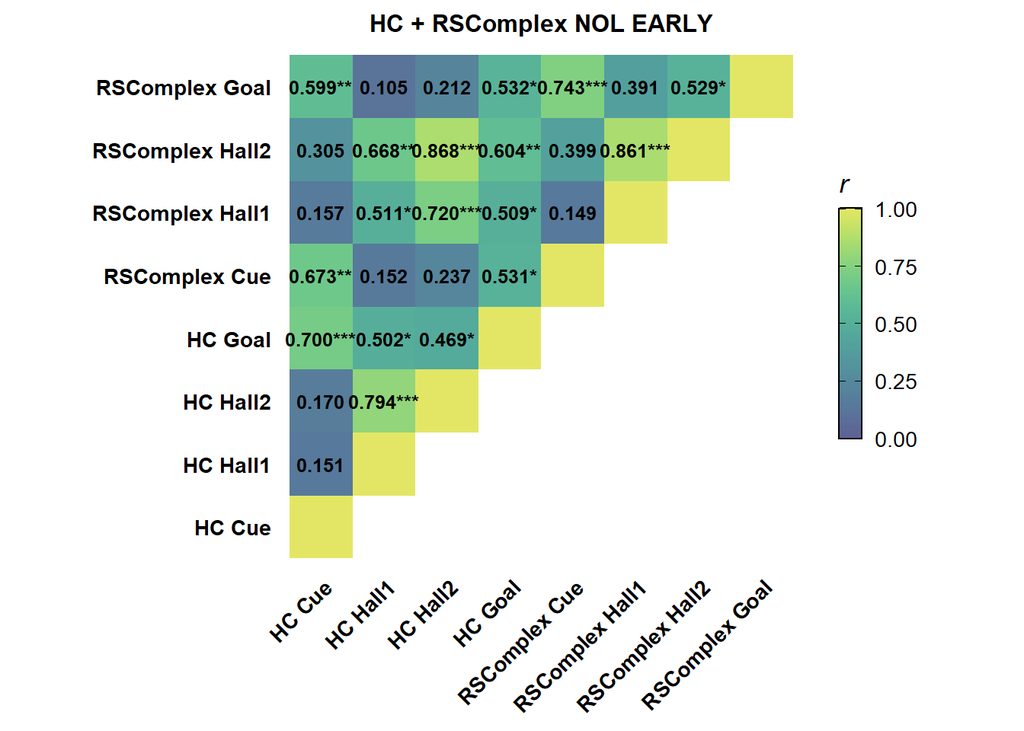

### HIPPOCAMPUS + RSComplex

HC + RSComplex NOL LATE MATRIX

## MASKING TRIANGLES

## PLOTTING

# CORRELATION MATRIX HC + RSComplex NOL LATE

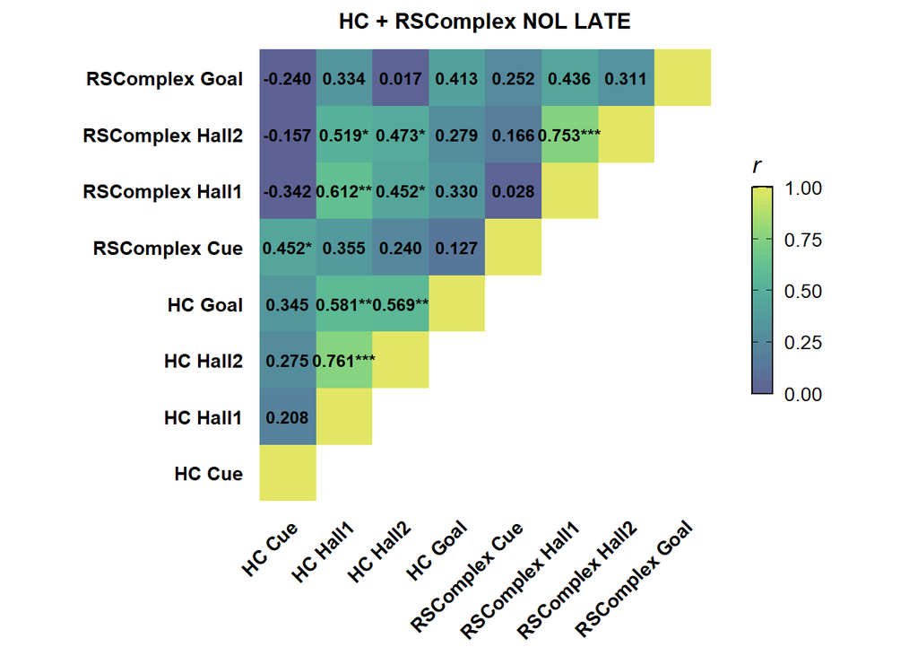

## RSC + RSComplex

# RSC + RSComplex NOL EARLY

## MASKING TRIANGLES

## PLOTTING

# CORRELATION MATRIX RSC + RSComplex NOL EARLY

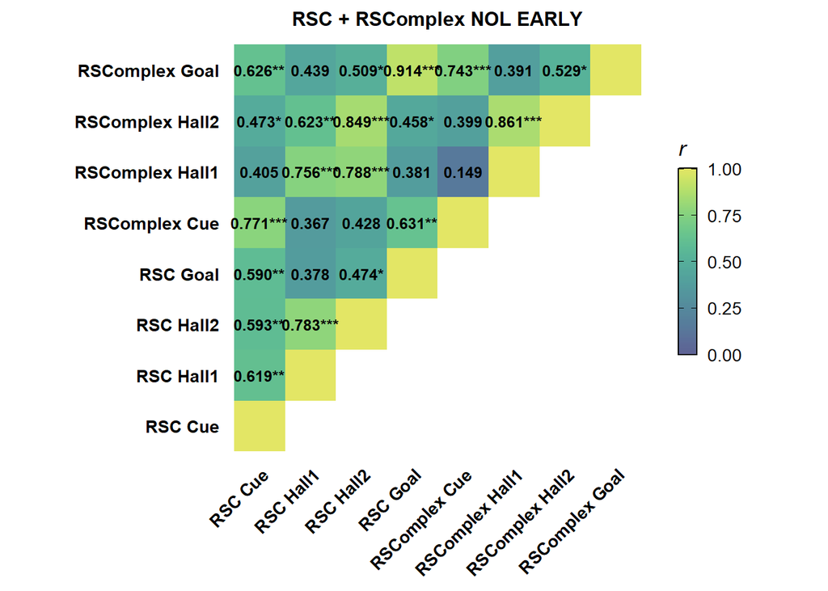

### RSC + RSComplex

RSC + RSComplex NOL LATE MATRIX

## MASKING TRIANGLES

## PLOTTING

# CORRELATION MATRIX RSC + RSComplex NOL LATE

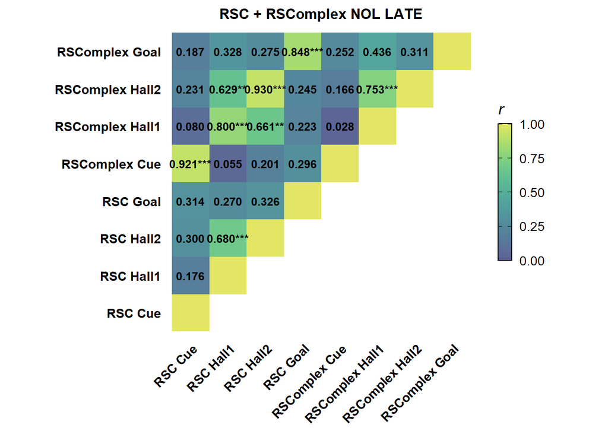